# **Replicating Adams et al. (2023)**

(Can’t We All Just Get Along?)

Daniel Benenson Markovits; Nadjim Fréchet; Rémi Thériault; Chris Yurris

2023-11-16

# Report & Conclusions

This replication study was preregistered at: https://osf.io/wd5fk. The source code for this report/project is available on GitHub: https://github.com/Nadjim10/replication_game_mtl_2023.

We replicated the main results of [Adams et al (2023)](https://doi.org/10.1017/S0003055422000491) ([PDF](https://www.ssoar.info/ssoar/bitstream/handle/document/87907/ssoar-ampolscirev-2023-1-adams_et_al-Cant_We_All_Just_Get.pdf)) for the Montreal Replication Games on June 14, 2023. The main results replicated with the authors’ initial code and with a simplification of the code using the `tidyverse` (the initial code was written in base R, see section Tidyverse Code Simplification). Our main substantive findings besides this replication is that the results of the paper were driven by left wing respondents and that the main findings were otherwise robust to various additional tests beyond those carried out by the authors.

We examined the results subsetted by the party family and by left and right blocks. We find highly significant results for left wing parties while right wing and centrist parties exhibit clear null results with some positively and others negatively signed. Substantively we believe this finding matters because of recent literature on democratic backsliding - the threat to democracy today comes mostly from the right Berman (2022) and it is right wing voters who are mostly willing to sacrifice democracy for instrumental reasons (Svolik 2023). It matters then that the portion of women MPs affects the attitudes of left wing voters and not the attitudes of the voters most likely to undermine democracy. We explain this treatment effect heterogeneity because of differences in party level attitudes towards female representation - left wing parties tend to have gender equality in representation written into their platforms. The conditional effect by evaluator party family is below (see section Affective Polarization by Party).

In addition, we wanted to clarify some aspects of the structure of the data that were not entirely clear from the paper, which is understandable given the paper is a short letter. The CSES data is an individual level dataset with more than 300,000 respondents. Weights are not consistently available for these data sets because of the structure of the CSES. Some country-election year iterations of the data have election weights (where respondents are weighted to election results) while others have demographic weights. In the absence of these weights the dataset is transformed into an (N ~= 2000) average of country-year-dyad affective scores - where each data point is an average of the out-party warmth scores in country I at time T from party A’s assessment of party B. The main analyses are performed on this data. We note that the absence of weighting may affect the results in a number of ways.

Finally, we also observed that `na.omit()` was used to exclude rows with missing observations even when the missing data were not involved in the analyses. However, listwise deletion is almost always most biased than a good imputation technique (van Ginkel, et al., 2020). Thus, it seems that at least for Table 1, the original authors excluded observations unnecessarily. In the last section, we impute the missing data through random forests before reproducing Table 1. We find that imputation does not affect the table coefficients statistical significance or substantive interpretation (see section Imputing Missing Data).

# Affective Polarization by Party

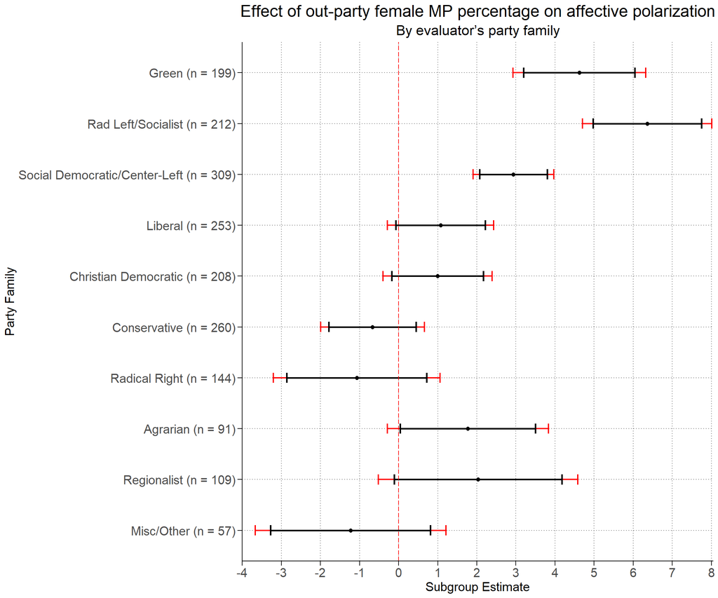

```r
party_spec <- function(x) {
  table1.2 <- lm(party_like ~ to_pfeml + rile_distance_s + prior_coalition +
    prior_opposition + as.factor(cntryyr), data = dta %>%
    subset(from_parfam == x), group = "Party")
  fig <- broom::tidy(table1.2) %>%
    mutate(par_fam = x, group = "Party") %>%
    subset(term == "to_pfeml")
  obs <- nobs(table1.2)
  cbind(fig, obs)
}

load("_data/dyadic_data_1-4-22.Rdata")

dta <- updated_data

# creating the country-year fixed effects
dta$cntryyr <- paste(dta$country, dta$year, sep = "")

## Removing smaller parties
dta <- subset(dta, dta$to_prior_seats >= 4)

vars <- c(
  "rile_distance_s", "prior_coalition", "prior_opposition", "econ_distance_s",
  "society_distance_s", "year", "country", "party_dislike", "party_like",
  "cntryyr", "to_pfeml", "to_prior_seats", "to_mp_number", "from_parfam",
  "from_left_bloc"
)
dta <- dta[vars]
dta <- na.omit(dta)

parties <- unique(dta$from_parfam)

bind_rows(map(parties, party_spec)) %>%
  mutate(
    par_fam2 = ifelse(par_fam == "10", "Green", par_fam),
    par_fam2 = ifelse(par_fam2 == "20", "Rad Left/Socialist", par_fam2),
    par_fam2 = ifelse(par_fam2 == "30", "Social Democratic/Center-Left",
                      par_fam2),
    par_fam2 = ifelse(par_fam2 == "40", "Liberal", par_fam2),
    par_fam2 = ifelse(par_fam2 == "50", "Christian Democratic", par_fam2),
    par_fam2 = ifelse(par_fam2 == "60", "Conservative", par_fam2),
    par_fam2 = ifelse(par_fam2 == "70", "Radical Right", par_fam2),
    par_fam2 = ifelse(par_fam2 == "80", "Agrarian", par_fam2),
    par_fam2 = ifelse(par_fam2 == "90", "Regionalist", par_fam2),
    par_fam2 = ifelse(par_fam2 == "95", "Misc/Other", par_fam2),
    par_fam2 = paste(par_fam2, " (n = ", obs, ")", sep = ""),
    par_fam2 = fct_reorder(par_fam2, desc(par_fam))
  ) %>%
  ggplot(aes(
    x = estimate, y = par_fam2, xmin = estimate - std.error * 1.96,
    xmax = estimate + std.error * 1.96
  )) +
  geom_point() +
  geom_errorbar(size = .75, color = "red", width = .2) +
  labs(
    x = "Subgroup Estimate", y = "Party Family",
    title = "Effect of out-party female MP percentage on affective polarization",
    subtitle = "By evaluator's party family"
  ) +
  geom_point(size = 2) +
  geom_hline(yintercept = 0, linetype = "longdash", color = "red") +
  geom_errorbar(
    aes(
      xmin = estimate - std.error * 1.645,
      xmax = estimate + std.error * 1.645
    ),
    width = 0.2, size = 1, color = "black"
  ) +
  geom_vline(xintercept = 0, color = "red", linetype = "longdash") +
  theme(
    panel.spacing = unit(.5, "lines"),
    strip.background = element_blank(),
    strip.placement = "outside",
    axis.text.x = element_text(size = 15),
    axis.title.y = element_text(size = 15),
    axis.title.x = element_text(size = 15),
    legend.position = "bottom",
    plot.caption = ggtext::element_markdown(color = "black", size = 17),
    axis.text.y = element_text(size = 15),
    plot.title = ggtext::element_markdown(size = 20, color = "black",
                                          hjust = 0.5),
    plot.subtitle = ggtext::element_markdown(size = 17, color = "black",
                                             hjust = 0.5),
    panel.grid.major.y = element_line(colour = "#6d6d6d", size = 0.5,
                                      linetype = "dotted"),
    panel.grid.major.x = element_line(colour = "#6d6d6d", size = 0.5,
                                      linetype = "dotted"),
    panel.background = element_rect(fill = "white"),
    axis.ticks.length.x = unit(.2, "cm"),
    axis.ticks.x = element_line(color = "black"),
    axis.ticks.y = element_line(color = "black"),
    axis.ticks.length.y = unit(.2, "cm"),
    panel.border = element_blank(),
    axis.line = element_line(color = "black"),
    strip.text.x = element_text(size = 15)
  ) +
  scale_x_continuous(limits = c(-4, 8.05), breaks = seq(-4, 8, 1),
                     expand = c(0, 0))
```

# Tidyverse Code Simplification

```r
############################################
############## CREATING FIGURE 1 ###########
############################################

load("_data/dyadic_data_1-4-22.Rdata") # Load data

dta_unique <- updated_data |>
  select(country, year, to_mp_number, to_rile, to_economy, to_society,
         to_femaleleader, to_pfeml) |> # Remove unneeded variables
  na.omit() |>
  distinct() # Keep only the unique parties being evaluated
```

## Figure 1

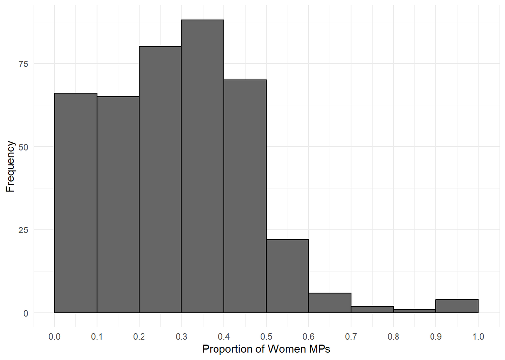

```r
# Graph 1
ggplot(dta_unique, aes(x = to_pfeml)) +
  geom_histogram(color = "black", fill = "grey40", binwidth = 0.1,
                 center = 0.25) +
  scale_x_continuous(breaks = seq(0, 1, 0.1)) +
  theme_minimal() +
  theme(plot.title = element_text(size = 12)) +
  ylab("Frequency") +
  xlab("Proportion of Women MPs")
```

```r
ggsave("_graphs/fig1.pdf", width = 12, height = 10)
```

## Table 1

```r
############################################
###### CREATING TABLE 1 COLUMNS 1 & 2 ######
############################################

dta <- updated_data |>
  mutate(cntryyr = paste(country, year, sep = "")) |>
  # creating the country-year fixed effects
  filter(to_prior_seats >= 4) |> # Removing smaller parties
  select(
    year, country, rile_distance_s, prior_coalition, prior_opposition,
    econ_distance_s, society_distance_s, party_dislike, party_like, cntryyr,
    to_pfeml, to_prior_seats, to_mp_number
  ) |> # selecting variables
  na.omit()

table1.1 <- lm(party_like ~ to_pfeml + as.factor(cntryyr), data = dta)
table1.2 <- lm(party_like ~ to_pfeml + rile_distance_s + prior_coalition +
                 prior_opposition + as.factor(cntryyr), data = dta)

# With clustered ses
stargazer(
  type = "html", table1.1, table1.2,
  add.lines = list(c("Country-Year Fixed Effects?", "Yes"),
                   c("Country-Level Clustered SEs?", "Yes")),
  se = starprep(table1.1, table1.2,
    clusters = dta$country
  ),
  keep = c(
    "to_pfeml", "rile_distance_s", "prior_coalition", "prior_opposition",
    "econ_distance_s", "society_distance_s"
  ),
  report = "vc*sp"
)
```

|  | *Dependent variable:* |  |
| --- | --- | --- |
|  | party_like |  |
|  | (1) | (2) |
| to_pfeml | 1.887*** | 1.726*** |
|  | (0.429) | (0.519) |
|  | p = 0.00002 | p = 0.001 |
| rile_distance_s |  | -0.596*** |
|  |  | (0.092) |
|  |  | p = 0.000 |
| prior_coalition |  | 0.943*** |
|  |  | (0.245) |
|  |  | p = 0.0002 |
| prior_opposition |  | 0.371*** |
|  |  | (0.108) |
|  |  | p = 0.001 |
| Country-Year Fixed Effects? | Yes |  |
| Country-Level Clustered SEs? | Yes |  |
| Observations | 1,842 | 1,842 |
| R<sup>2</sup> | 0.191 | 0.340 |
| Adjusted R<sup>2</sup> | 0.154 | 0.308 |
| Residual Std. Error | 1.403 (df = 1760) | 1.268 (df = 1757) |
| F Statistic | 5.136*** (df = 81; 1760) | 10.776*** (df = 84; 1757) |
| *Note:* | p<0.1; p<0.05; p<0.01 |  |

```r
cat("### Table1.1")
```

### Table1.1

```r
format3 <- function(x) {
  formatC(x, format = "f", digits = 3)
}

table1.1 |>
  report_table() |>
  filter(!grepl("cntryyr|Intercept", Parameter)) |>
  nice_table(highlight = TRUE, short = TRUE,
             col.format.custom = 2, format.custom = "format3")
```

| Parameter | b | CI | t | df | p | b* | Std_Coefficient_CI_low | Std_Coefficient_CI_high | Fit | 95% CI |
| --- | --- | --- | --- | --- | --- | --- | --- | --- | --- | --- |
| to pfeml | 1.887 | 0.95 | 7.17 | 1,760 | < .001*** | 0.20 | 0.14 | 0.25 |  | [1.37, 2.40] |
|  | NA |  |  |  |  |  |  |  |  |  |
| AIC | NA |  |  |  |  |  |  |  | 6,556.87 |  |
| AICc | NA |  |  |  |  |  |  |  | 6,564.80 |  |
| BIC | NA |  |  |  |  |  |  |  | 7,014.91 |  |
| R2 | NA |  |  |  |  |  |  |  | 0.19 |  |
| R2 (adj.) | NA |  |  |  |  |  |  |  | 0.15 |  |
| Sigma | NA |  |  |  |  |  |  |  | 1.40 |  |

```r
cat("### Table1.2")
```

### Table1.2

```r
table1.2 |>
  report_table() |>
  filter(!grepl("cntryyr|Intercept", Parameter)) |>
  nice_table(highlight = TRUE, short = TRUE,
             col.format.custom = 2, format.custom = "format3")
```

| Parameter | b | CI | t | df | p | b* | Std_Coefficient_CI_low | Std_Coefficient_CI_high | Fit | 95% CI |
| --- | --- | --- | --- | --- | --- | --- | --- | --- | --- | --- |
| to pfeml | 1.726 | 0.95 | 7.23 | 1,757 | < .001*** | 0.18 | 0.13 | 0.23 |  | [1.26, 2.19] |
| rile distance s | -0.596 | 0.95 | -17.27 | 1,757 | < .001*** | -0.39 | -0.43 | -0.34 |  | [-0.66, -0.53] |
| prior coalition | 0.943 | 0.95 | 8.88 | 1,757 | < .001*** | 0.19 | 0.15 | 0.24 |  | [0.73, 1.15] |
| prior opposition | 0.371 | 0.95 | 5.38 | 1,757 | < .001*** | 0.12 | 0.08 | 0.16 |  | [0.24, 0.51] |
|  | NA |  |  |  |  |  |  |  |  |  |
| AIC | NA |  |  |  |  |  |  |  | 6,188.30 |  |
| AICc | NA |  |  |  |  |  |  |  | 6,196.82 |  |
| BIC | NA |  |  |  |  |  |  |  | 6,662.90 |  |
| R2 | NA |  |  |  |  |  |  |  | 0.34 |  |
| R2 (adj.) | NA |  |  |  |  |  |  |  | 0.31 |  |
| Sigma | NA |  |  |  |  |  |  |  | 1.27 |  |

```r
############################################
###### CREATING TABLE 2 COLUMNS 3 & 4 ######
############################################

# Note in gendered data, the party_like and party_dislike variable indicate
# mean levels of like/dislike for party by ALL partisans
# the "dislike" variable indicates level of dislike towards out-party
# by partisans of specified gender

dta <- readRDS("_data/gender_disagregated_8-8-21.rds") |>
  mutate(countryyear = paste(country, dta$year, sep = "")) |>
  # creating the country-year fixed effects
  filter(to_prior_seats >= 4) |> # Removing smaller parties
  mutate(like = 10 - dislike) |>
  # Create Like variable for gendered data from dislike
  select(
    year, country, rile_distance_s, prior_coalition, prior_opposition,
    econ_distance_s, society_distance_s, to_pfeml,
    countryyear, gender, like, dislike, to_prior_seats
  ) |>
  na.omit()

# Only men subset
dta_male <- dta |> filter(gender == 1)
dta_female <- dta |> filter(gender == 2)

dta_female$countryyear <- as.factor(dta_female$countryyear)

tableS2.3 <- lm(like ~ to_pfeml + rile_distance_s + prior_coalition +
  prior_opposition + countryyear, data = dta_female)
tableS2.4 <- lm(like ~ to_pfeml + rile_distance_s + prior_coalition +
  prior_opposition + countryyear, data = dta_male)
```

## Table S2 (women)

```r
# With clustered ses - women
stargazer(
  type = "html", tableS2.3,
  add.lines = list(c("Country-Year Fixed Effects?", "Yes"),
                   c("Out-Party Fixed Effects?", "Yes"),
                   c("Country-Level Clustered ses?", "Yes")),
  se = starprep(tableS2.3,
    clusters = dta_female$country
  ),
  keep = c("to_pfeml", "rile_distance_s", "prior_coalition",
           "prior_opposition", "to_pfeml2"),
  report = "vc*sp"
)
```

|  | *Dependent variable:* |
| --- | --- |
|  | like |
| to_pfeml | 2.149*** |
|  | (0.479) |
|  | p = 0.00001 |
| rile_distance_s | -0.601*** |
|  | (0.093) |
|  | p = 0.000 |
| prior_coalition | 0.976*** |
|  | (0.215) |
|  | p = 0.00001 |
| prior_opposition | 0.356*** |
|  | (0.104) |
|  | p = 0.001 |
| Country-Year Fixed Effects? | Yes |
| Out-Party Fixed Effects? | Yes |
| Country-Level Clustered ses? | Yes |
| Observations | 1,836 |
| R<sup>2</sup> | 0.343 |
| Adjusted R<sup>2</sup> | 0.252 |
| Residual Std. Error | 1.405 (df = 1613) |
| F Statistic | 3.792*** (df = 222; 1613) |
| *Note:* | p<0.1; p<0.05; p<0.01 |

```r
cat("### TableS2.3")
```

### TableS2.3

```r
tableS2.3 |>
  report_table() |>
  filter(!grepl("countryyear|Intercept", Parameter)) |>
  nice_table(highlight = TRUE, short = TRUE,
             col.format.custom = 2, format.custom = "format3")
```

| Parameter | b | CI | t | df | p | b* | Std_Coefficient_CI_low | Std_Coefficient_CI_high | Fit | 95% CI |
| --- | --- | --- | --- | --- | --- | --- | --- | --- | --- | --- |
| to pfeml | 2.149 | 0.95 | 8.14 | 1,613 | < .001*** | 0.21 | 0.16 | 0.26 |  | [1.63, 2.67] |
| rile distance s | -0.601 | 0.95 | -15.10 | 1,613 | < .001*** | -0.37 | -0.41 | -0.32 |  | [-0.68, -0.52] |
| prior coalition | 0.976 | 0.95 | 7.84 | 1,613 | < .001*** | 0.19 | 0.14 | 0.24 |  | [0.73, 1.22] |
| prior opposition | 0.356 | 0.95 | 4.61 | 1,613 | < .001*** | 0.11 | 0.06 | 0.15 |  | [0.20, 0.51] |
|  | NA |  |  |  |  |  |  |  |  |  |
| AIC | NA |  |  |  |  |  |  |  | 6,668.41 |  |
| AICc | NA |  |  |  |  |  |  |  | 6,730.98 |  |
| BIC | NA |  |  |  |  |  |  |  | 7,903.85 |  |
| R2 | NA |  |  |  |  |  |  |  | 0.34 |  |
| R2 (adj.) | NA |  |  |  |  |  |  |  | 0.25 |  |
| Sigma | NA |  |  |  |  |  |  |  | 1.40 |  |

## Table S2 (men)

```r
# With clustered ses - men
stargazer(
  type = "html", tableS2.4,
  add.lines = list(c("Country-Year Fixed Effects?", "Yes"),
                   c("Out-Party Fixed Effects?", "Yes"),
                   c("Country-Level Clustered ses?", "Yes")),
  se = starprep(tableS2.4,
    clusters = dta_male$country
  ),
  keep = c("to_pfeml", "rile_distance_s", "prior_coalition",
           "prior_opposition", "to_pfeml2"),
  report = "vc*sp"
)
```

|  | *Dependent variable:* |
| --- | --- |
|  | like |
| to_pfeml | 1.189*** |
|  | (0.428) |
|  | p = 0.006 |
| rile_distance_s | -0.617*** |
|  | (0.080) |
|  | p = 0.000 |
| prior_coalition | 0.988*** |
|  | (0.231) |
|  | p = 0.00002 |
| prior_opposition | 0.342*** |
|  | (0.109) |
|  | p = 0.002 |
| Country-Year Fixed Effects? | Yes |
| Out-Party Fixed Effects? | Yes |
| Country-Level Clustered ses? | Yes |
| Observations | 1,833 |
| R<sup>2</sup> | 0.351 |
| Adjusted R<sup>2</sup> | 0.260 |
| Residual Std. Error | 1.361 (df = 1605) |
| F Statistic | 3.830*** (df = 227; 1605) |
| *Note:* | p<0.1; p<0.05; p<0.01 |

```r
cat("### Table S2.4")
```

### Table S2.4

```r
tableS2.4 |>
  report_table() |>
  filter(!grepl("countryyear|Intercept", Parameter)) |>
  nice_table(highlight = TRUE, short = TRUE,
             col.format.custom = 2, format.custom = "format3")
```

| Parameter | b | CI | t | df | p | b* | Std_Coefficient_CI_low | Std_Coefficient_CI_high | Fit | 95% CI |
| --- | --- | --- | --- | --- | --- | --- | --- | --- | --- | --- |
| to pfeml | 1.189 | 0.95 | 4.65 | 1,605 | < .001*** | 0.12 | 0.07 | 0.17 |  | [0.69, 1.69] |
| rile distance s | -0.617 | 0.95 | -16.02 | 1,605 | < .001*** | -0.39 | -0.43 | -0.34 |  | [-0.69, -0.54] |
| prior coalition | 0.988 | 0.95 | 8.12 | 1,605 | < .001*** | 0.20 | 0.15 | 0.24 |  | [0.75, 1.23] |
| prior opposition | 0.342 | 0.95 | 4.54 | 1,605 | < .001*** | 0.11 | 0.06 | 0.15 |  | [0.19, 0.49] |
|  | NA |  |  |  |  |  |  |  |  |  |
| AIC | NA |  |  |  |  |  |  |  | 6,547.17 |  |
| AICc | NA |  |  |  |  |  |  |  | 6,612.89 |  |
| BIC | NA |  |  |  |  |  |  |  | 7,809.81 |  |
| R2 | NA |  |  |  |  |  |  |  | 0.35 |  |
| R2 (adj.) | NA |  |  |  |  |  |  |  | 0.26 |  |
| Sigma | NA |  |  |  |  |  |  |  | 1.36 |  |

```r
############################################
############ CREATING TABLE S3 #############
############################################

load("_data/dyadic_data_1-4-22.Rdata")

dta <- updated_data |>
  mutate(cntryyr = paste(country, year, sep = "")) |>
  # creating the country-year fixed effects
  select(
    year, country, rile_distance_s, prior_coalition, prior_opposition,
    econ_distance_s, society_distance_s, party_dislike, party_like, cntryyr,
    to_pfeml, from_rile, to_rile, from_left_bloc, from_right_bloc, to_left_bloc,
    to_right_bloc, from_parfam, to_parfam, to_prior_seats
  ) |>
  na.omit()

dta_nrr <- dta |> filter(to_parfam != 70)
dta_nrr <- dta_nrr |> filter(from_parfam != 70)

# Remove small parties, with fewer than 4 seats

dta_small_nrr <- dta_nrr |> filter(to_prior_seats >= 4)

table.S3 <- lm(party_like ~ to_pfeml + rile_distance_s + prior_coalition +
                 prior_opposition + as.factor(country), data = dta_small_nrr)
```

## Table S3 (stargazer)

```r
stargazer(
  type = "html", table.S3,
  add.lines = list(c("Country-Year Fixed Effects?", "Yes"),
                   c("Country-Level Clustered ses?", "Yes")),
  se = starprep(table.S3,
    clusters = dta_small_nrr$country
  ),
  keep = c(
    "to_pfeml", "rile_distance_s", "prior_coalition", "prior_opposition",
    "econ_distance_s", "society_distance_s"
  ),
  report = "vc*sp"
)
```

|  | *Dependent variable:* |
| --- | --- |
|  | party_like |
| to_pfeml | 0.893*** |
|  | (0.260) |
|  | p = 0.001 |
| rile_distance_s | -0.576*** |
|  | (0.082) |
|  | p = 0.000 |
| prior_coalition | 0.952*** |
|  | (0.214) |
|  | p = 0.00001 |
| prior_opposition | 0.470*** |
|  | (0.093) |
|  | p = 0.00000 |
| Country-Year Fixed Effects? | Yes |
| Country-Level Clustered ses? | Yes |
| Observations | 1,590 |
| R<sup>2</sup> | 0.311 |
| Adjusted R<sup>2</sup> | 0.301 |
| Residual Std. Error | 1.228 (df = 1566) |
| F Statistic | 30.761*** (df = 23; 1566) |
| *Note:* | p<0.1; p<0.05; p<0.01 |

```r
cat("### Table S3 (summary)")
```

### Table S3 (summary)

```r
table.S3 |>
  report_table() |>
  filter(!grepl("country|Intercept", Parameter)) |>
  nice_table(highlight = TRUE, short = TRUE,
             col.format.custom = 2, format.custom = "format3")
```

| Parameter | b | CI | t | df | p | b* | Std_Coefficient_CI_low | Std_Coefficient_CI_high | Fit | 95% CI |
| --- | --- | --- | --- | --- | --- | --- | --- | --- | --- | --- |
| to pfeml | 0.893 | 0.95 | 3.60 | 1,566 | < .001*** | 0.10 | 0.04 | 0.15 |  | [0.41, 1.38] |
| rile distance s | -0.576 | 0.95 | -15.98 | 1,566 | < .001*** | -0.37 | -0.42 | -0.33 |  | [-0.65, -0.51] |
| prior coalition | 0.952 | 0.95 | 9.02 | 1,566 | < .001*** | 0.20 | 0.16 | 0.25 |  | [0.75, 1.16] |
| prior opposition | 0.470 | 0.95 | 6.77 | 1,566 | < .001*** | 0.16 | 0.11 | 0.20 |  | [0.33, 0.61] |
|  | NA |  |  |  |  |  |  |  |  |  |
| AIC | NA |  |  |  |  |  |  |  | 5,191.16 |  |
| AICc | NA |  |  |  |  |  |  |  | 5,191.99 |  |
| BIC | NA |  |  |  |  |  |  |  | 5,325.44 |  |
| R2 | NA |  |  |  |  |  |  |  | 0.31 |  |
| R2 (adj.) | NA |  |  |  |  |  |  |  | 0.30 |  |
| Sigma | NA |  |  |  |  |  |  |  | 1.23 |  |

```r
############################################
############ CREATING TABLE S3B ############
############################################

# Load
load("_data/dyadic_data_1-4-22.Rdata")

dta <- updated_data |>
  select(
    year, country, rile_distance_s, prior_coalition,
    prior_opposition, econ_distance_s, society_distance_s,
    party_dislike, party_like, to_parfam, to_left_bloc,
    to_right_bloc, cntryyr, to_pfeml, to_prior_seats
  ) |>
  na.omit()

# Remove small parties, with fewer than 4 seats
dta_small <- dta |> filter(to_prior_seats >= 4)

table.3B.1 <- lm(party_like ~ to_pfeml + as.factor(cntryyr), data = dta_small)
table.3B.2 <- lm(party_like ~ to_pfeml + rile_distance_s + to_left_bloc +
                   prior_coalition + prior_opposition + as.factor(cntryyr),
                 data = dta_small)
```